# **Homework 4 Classification**

Enes Ata Oruç

29.01.2021

The aim of this homework is to compare the performance of penalized regression approaches, decision trees, support vector machines and tree-based ensembles. We are asked to find 4 datasets for a classification task from different domains. This report is created for Student Performance Dataset.

### Student Performance Data:

This dataset contains 649 observations and 33 features about student performance in Porteguese Language. This dataset also mixed with numeric and categorical features and was modeled under binary/five-level classification and regression tasks. Student Performance Data in Porteguese Class: (https://archive.ics.uci.edu/ml/datasets/student%2Bperformance)

There is also a paper published about this dataset. There will be Pass and Fail condition according to student grades.

Related paper: http://www3.dsi.uminho.pt/pcortez/student.pdf

```r
# important libraries
library(tidyverse)
library(data.table)
library(rpart)
library(rattle)
library(rpart.plot)
library(RColorBrewer)
library(mlbench)
library(MLmetrics)
library(dplyr)
library(caret)
library(readr)
```

G1,G2 and G3 removed from the data because they directly correlated with the Letter grades. So, overfiting prevented.

```r
stud_dt <- fread("student.csv")
stud_dt$Record = ifelse(stud_dt$G3 >=10, 1,2)
stud_dt$Record = as.numeric(stud_dt$Record)
stud_dt$G1 <- NULL
stud_dt$G2 <- NULL
stud_dt$G3 <- NULL
stud_dt$Letter <- NULL
```

## 1. Penalized Regression Approach:

```r
library(glmnet)
stud_dt$Record <- as.numeric(stud_dt$Record)
smp_size_pra <- floor((2/3) * nrow(stud_dt))

# set the seed to make your partition reproducible
set.seed(1234)
train_ind_pra <- sample(seq_len(nrow(stud_dt)), size = smp_size_pra)

train_pra <- stud_dt[train_ind_pra, ]
test_pra <- stud_dt[-train_ind_pra, ]


health_mat_2 <- data.matrix(train_pra)
cvfit=cv.glmnet(health_mat_2, train_pra$Record,family='gaussian',nfolds=10)
cvfit
```

```
##
## Call:  cv.glmnet(x = health_mat_2, y = train_pra$Record, nfolds = 10,      family = "gaussian")
##
## Measure: Mean-Squared Error
##
##      Lambda  Measure        SE Nonzero
## min 0.01055 0.000114 1.095e-05       1
## 1se 0.01055 0.000114 1.095e-05       1
```

```r
lambda_min <- cvfit$lambda.min
lambda_min
```

```
## [1] 0.01055229
```

```r
# Lasso with Train Set
lassofit <- glmnet(x=health_mat_2, y = train_pra$Record, alpha = 1,lambda = lambda_min)
lasso_train_predicted <-as.numeric(predict(lassofit, newx=data.matrix(train_pra)))

# RMSE for Train Lasso
caret::RMSE(lasso_train_predicted, train_pra$Record)
```

[output not shown]

```r
# Lasso with Test Set
lasso_test_predicted <-as.numeric(predict(lassofit, newx=data.matrix(test_pra)))
# RMSE for Test Lasso
caret::RMSE(lasso_test_predicted, test_pra$Record)
```

```
## [1] 0.0104681
```

## 2. Decision Tree Approach:

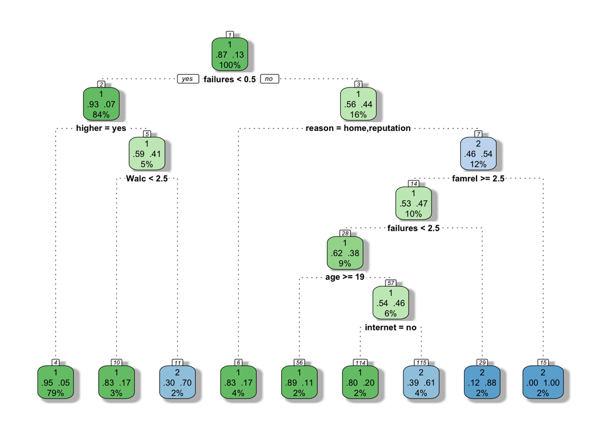

```r
# 2/3 of the sample size stud_dt
stud_dt$Record <- as.numeric(stud_dt$Record)
smp_size_dt <- floor((2/3) * nrow(stud_dt))

# set the seed to make your partition reproducible
set.seed(123)
train_ind_dt <- sample(seq_len(nrow(stud_dt)), size = smp_size_dt)

train_dt_stud <- stud_dt[train_ind_dt, ]
test_dt_stud <- stud_dt[-train_ind_dt, ]

#method is "class" because I want to perform classification
mytree_stud <- rpart(
  Record ~ .,
  data = train_dt_stud,
  method = "class"
)

# plot mytree
fancyRpartPlot(mytree_stud, caption = NULL)
```

```r
printcp(mytree_stud) # display the results
```

```
##
## Classification tree:
## rpart(formula = Record ~ ., data = train_dt_stud, method = "class")
##
## Variables actually used in tree construction:
## [1] age      failures famrel   higher   internet reason   Walc
##
## Root node error: 58/432 = 0.13426
##
## n= 432
##
##         CP nsplit rel error  xerror    xstd
## 1 0.056034      0   1.00000 1.00000 0.12217
## 2 0.034483      4   0.77586 1.05172 0.12479
## 3 0.010000      8   0.63793 0.91379 0.11757
```

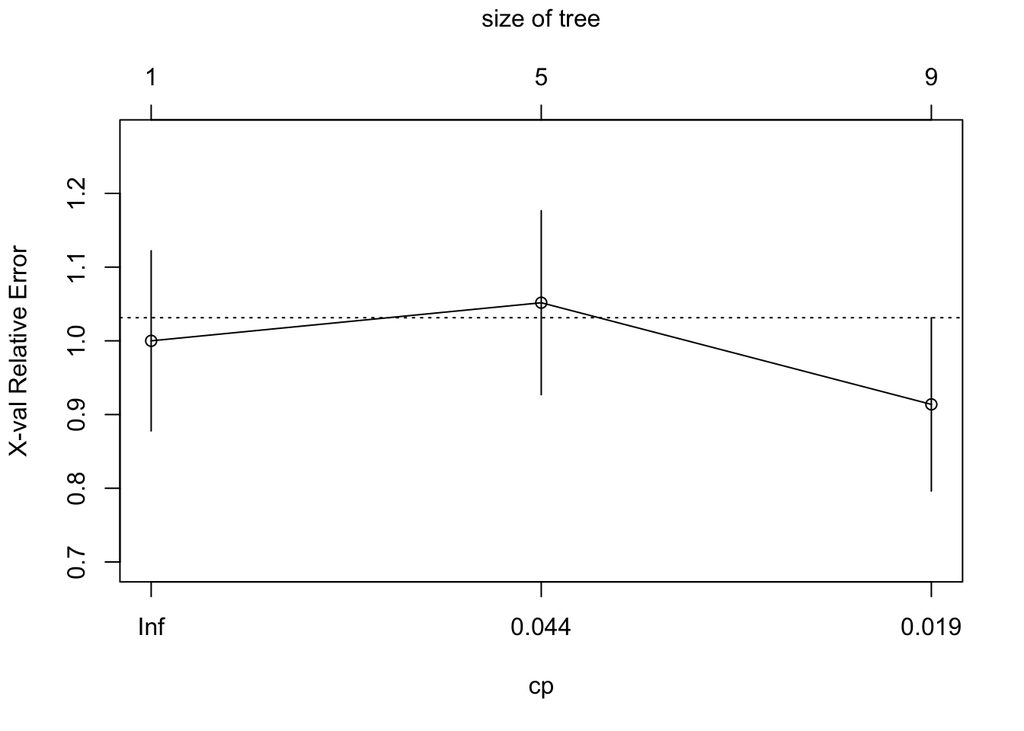

```r
plotcp(mytree_stud) # visualize cross-validation results
```

```r
summary(mytree_stud) # detailed summary of splits
```

```
## Call:
## rpart(formula = Record ~ ., data = train_dt_stud, method = "class")
##   n= 432
##
##           CP nsplit rel error    xerror      xstd
## 1 0.05603448      0 1.0000000 1.0000000 0.1221743
## 2 0.03448276      4 0.7758621 1.0517241 0.1247906
## 3 0.01000000      8 0.6379310 0.9137931 0.1175676
##
## Variable importance
## failures   higher      age     Walc   reason   famrel      sex internet
##       35       10        7        7        7        6        4        4
##     Medu guardian absences     Dalc     Mjob     Fjob     Fedu     paid
##        3        3        2        2        2        2        1        1
##  Pstatus   school freetime   health
##        1        1        1        1
##
## Node number 1: 432 observations,    complexity param=0.05603448
##   predicted class=1  expected loss=0.1342593  P(node) =1
##     class counts:   374    58
##    probabilities: 0.866 0.134
##   left son=2 (362 obs) right son=3 (70 obs)
##   Primary splits:
##       failures  < 0.5  to the left,  improve=15.910690, (0 missing)
##       higher    splits as  RL,       improve=11.528080, (0 missing)
##       school    splits as  LR,       improve= 9.780093, (0 missing)
##       studytime < 1.5  to the right, improve= 3.120507, (0 missing)
##       Fedu      < 2.5  to the right, improve= 2.116109, (0 missing)
##   Surrogate splits:
##       age      < 18.5 to the left,  agree=0.861, adj=0.143, (0 split)
##       guardian splits as  LLR,      agree=0.850, adj=0.071, (0 split)
##       Fedu     < 0.5  to the right, agree=0.840, adj=0.014, (0 split)
##
## Node number 2: 362 observations,    complexity param=0.03448276
##   predicted class=1  expected loss=0.07458564  P(node) =0.837963
##     class counts:   335    27
##    probabilities: 0.925 0.075
##   left son=4 (340 obs) right son=5 (22 obs)
##   Primary splits:
##       higher    splits as  RL,       improve=5.2418940, (0 missing)
```

[output cut: 128 more lines]

```
##       Mjob    splits as  LRRR-,    agree=0.786, adj=0.4, (0 split)
##       sex     splits as  LR,       agree=0.750, adj=0.3, (0 split)
##       Walc    < 1.5  to the left,  agree=0.750, adj=0.3, (0 split)
##       school  splits as  RL,       agree=0.714, adj=0.2, (0 split)
##       Pstatus splits as  LR,       agree=0.714, adj=0.2, (0 split)
##
## Node number 114: 10 observations
##   predicted class=1  expected loss=0.2  P(node) =0.02314815
##     class counts:     8     2
##    probabilities: 0.800 0.200
##
## Node number 115: 18 observations
##   predicted class=2  expected loss=0.3888889  P(node) =0.04166667
##     class counts:     7    11
##    probabilities: 0.389 0.611
```

```r
#prediction
predictions <- predict(mytree_stud, test_dt_stud, type = "class")
predictions = as.numeric(predictions)
# Prediction measures
table(test_dt_stud$Record, predictions)
```

```
##    predictions
##       1   2
##   1 165  10
##   2  29  13
```

```r
#RMSE Value for performance test
RMSE(test_dt_stud$Record,predictions)
```

```
## [1] 0.4239381
```

## 3. Random Forest Approach

```r
#Random Forest Approach
stud_dt$Record = as.factor(stud_dt$Record)
#Test/train split
smp_size <- floor((2/3) * nrow(stud_dt))

# set the seed to make your partition reproducible
set.seed(1234)
train_ind <- sample(seq_len(nrow(stud_dt)), size = smp_size)
train_rf <- stud_dt[train_ind, ]
test_rf <- stud_dt[-train_ind, ]
x <- train_rf[,1:30]
y <- train_rf[,31]
#RF Implement
control <- trainControl(method="repeatedcv", number=10, repeats=3)
seed <- 5
metric <- "Accuracy"
set.seed(1234)
mtry <- sqrt(ncol(x))
tunegrid <- expand.grid(.mtry=mtry)
rf_default <- train(Record~., data=train_rf, method="rf", metric=metric, tuneGrid=tunegrid, trControl=control)
print(rf_default)
```

```
## Random Forest
##
## 432 samples
##  30 predictor
##   2 classes: '1', '2'
##
## No pre-processing
## Resampling: Cross-Validated (10 fold, repeated 3 times)
## Summary of sample sizes: 389, 390, 388, 388, 388, 389, ...
## Resampling results:
##
##   Accuracy  Kappa
##   0.849599  0.1356965
##
## Tuning parameter 'mtry' was held constant at a value of 5.477226
```

```r
# accuracy calculation of prediction
predictForest_2 = predict(rf_default, newdata = test_rf)
table(test_rf$Record, predictForest_2)
```

```
##    predictForest_2
##       1   2
##   1 183   1
##   2  28   5
```

```r
test_rf$Record<-as.numeric(test_rf$Record)
#RMSE Value for performance test
predictForest_2 <- as.numeric(predictForest_2)
RMSE(test_rf$Record,predictForest_2)
```

```
## [1] 0.3655688
```

## 4. Stochastic Gradient Approach:

```r
library(gbm)

stud_dt$Record = as.numeric(stud_dt$Record)
stud_dt$age = as.factor(stud_dt$age)
stud_dt$sex = as.factor(stud_dt$sex)
stud_dt$school = as.factor(stud_dt$school)
stud_dt$address = as.factor(stud_dt$address)
stud_dt$famsize = as.factor(stud_dt$famsize)
stud_dt$Pstatus = as.factor(stud_dt$Pstatus)
stud_dt$Mjob = as.factor(stud_dt$Mjob)
stud_dt$Fjob = as.factor(stud_dt$Fjob)
stud_dt$reason = as.factor(stud_dt$reason)
stud_dt$guardian = as.factor(stud_dt$guardian)
stud_dt$schoolsup = as.factor(stud_dt$schoolsup)
stud_dt$famsup = as.factor(stud_dt$famsup)
stud_dt$paid = as.factor(stud_dt$paid)
stud_dt$activities = as.factor(stud_dt$activities)
stud_dt$nursery = as.factor(stud_dt$nursery)
stud_dt$higher = as.factor(stud_dt$higher)
stud_dt$internet = as.factor(stud_dt$internet)
stud_dt$romantic = as.factor(stud_dt$romantic)
#Test/train split
smp_size <- floor((2/3) * nrow(stud_dt))

# set the seed to make your partition reproducible
set.seed(1234)

train_ind <- sample(seq_len(nrow(stud_dt)), size = smp_size)
train_sgb <- stud_dt[train_ind, ]
test_sgb <- stud_dt[-train_ind, ]
# randomize data
random_index <- sample(1:nrow(train_sgb), nrow(train_sgb))
random_sgb_train <- train_sgb[random_index, ]

# modify hyperparameter grid
hyper_grid <- expand.grid(
  shrinkage = c(.01, .05, .1),
  interaction.depth = c(3, 5, 7),
  n.minobsinnode = c(5, 7, 10),
  bag.fraction = c(.65, .8, 1),
  optimal_trees = 0,               # a place to dump results
  min_RMSE = 0                     # a place to dump results
)

# total number of combinations
nrow(hyper_grid)
```

```
## [1] 81
```

```r
## [1] 81

# grid search
for(i in 1:nrow(hyper_grid)) {

  # reproducibility
  set.seed(123)

  # train model
  gbm.tune <- gbm(formula = Record ~ .,
    distribution = "gaussian",
    data = random_sgb_train,
    n.trees = 600,
    interaction.depth = hyper_grid$interaction.depth[i],
    shrinkage = hyper_grid$shrinkage[i],
    n.minobsinnode = hyper_grid$n.minobsinnode[i],
    bag.fraction = hyper_grid$bag.fraction[i],
    train.fraction = .75,
    n.cores = NULL, # will use all cores by default
    verbose = FALSE
  )

  # add min training error and trees to grid
  hyper_grid$optimal_trees[i] <- which.min(gbm.tune$valid.error)
  hyper_grid$min_RMSE[i] <- sqrt(min(gbm.tune$valid.error))
}

hyper_grid %>%
  dplyr::arrange(min_RMSE) %>%
  head(10)
```

```
##    shrinkage interaction.depth n.minobsinnode bag.fraction optimal_trees
## 1       0.10                 7             10         0.65            10
## 2       0.05                 3             10         0.65            33
## 3       0.05                 7             10         0.80            27
## 4       0.05                 5             10         0.65            30
## 5       0.05                 7              7         1.00            41
## 6       0.10                 7              7         1.00            11
## 7       0.10                 7              5         0.80            10
## 8       0.10                 5             10         0.65            11
## 9       0.10                 3             10         0.65            24
## 10      0.01                 7             10         0.65           170
##     min_RMSE
## 1  0.3144407
## 2  0.3168651
## 3  0.3170143
## 4  0.3174361
## 5  0.3175028
## 6  0.3187618
## 7  0.3189169
## 8  0.3190462
## 9  0.3191172
## 10 0.3192846
```

```r
# for reproducibility
set.seed(123)

# train GBM model
gbm.fit.final <- gbm(formula = Record ~ .,
  distribution = "gaussian",
  data = train_sgb,
  n.trees = 483,
  interaction.depth = 5,
  shrinkage = 0.1,
  n.minobsinnode = 5,
  bag.fraction = .65,
  train.fraction = 1,
  n.cores = NULL, # will use all cores by default
  verbose = FALSE
  )
# predict values for test data
pred <- predict(gbm.fit.final, n.trees = gbm.fit.final$n.trees, test_sgb)

# results
caret::RMSE(pred, test_sgb$Record)
```

```
## [1] 0.3669504
```

## Compare Results

Penalized Regression Approach

```r
# RMSE for Test Lasso
caret::RMSE(lasso_test_predicted, test_pra$Record)
```

```
## [1] 0.0104681
```

Decision Tree Approach

```r
#RMSE Value for performance test DT
RMSE(test_dt_stud$Record,predictions)
```

```
## [1] 0.4239381
```

Random Forest

```r
# RMSE Value for performance test
predictForest_2 <- as.numeric(predictForest_2)
RMSE(test_rf$Record,predictForest_2)
```

```
## [1] 0.3655688
```

Stochastic Gradient Boosting

```r
# results
caret::RMSE(pred, test_sgb$Record)
```

```
## [1] 0.3669504
```

When we looked at the RMSE values I believe there is some miscalculation happened in lasso approach because its value doesn’t seem realistic. This lasso situation also happened on different datasets. But I tuned the other 3 approaches. Because of this meaningful assumptions, I believe they gave more reliable results.

So, when we consider the other approaches Random Forest gave the best classification result on Student performance data with lowest RMSE value. But Stochastic Gradient Boosting also performed similar to Random Forest. Targer determined as Pass or Fail class. This target column determined by the researches that provided this dataset.